# DS2 Lab2 - Tree-based methods

Data Science 2: Machine Learning Tools - CEU 2021

Janos K. Divenyi, Jeno Pal

2021-03-01

```r
library(tidyverse)
library(ggplot2)
theme_set(theme_minimal())

library(h2o)
h2o.init()
```

[output not shown]

[output not shown]

```r
h2o.no_progress()
```

## Random forests

You covered decision trees in DA3. Using it as a base model lets us build many different models with less variance and better predictive power. The downside: interpretation gets harder.

Idea: as individual trees are unstable and have high variance, train many versions on bootstrap samples (“Bagging”: Bootstrap AGGregation). Then predict: take the average (regression), majority vote / class share (classification).

Random forests: randomly constrain the set of predictor variables used to grow trees (randomly select at each split). Goal: avoid correlated trees that are very similar to each other, still with the aim of decreasing variance.

```r
data <- as_tibble(ISLR::Hitters)
skimr::skim(data)
```

```r
# goal: predict log salary
data <- as_tibble(ISLR::Hitters) %>%
  drop_na(Salary) %>%
  mutate(log_salary = log(Salary), Salary = NULL)

h2o_data <- as.h2o(data)
```

```
data.table cannot be used without R package bit64 version 0.9.7 or higher.  Please upgrade to take advangage of data.table speedups.
```

```r
my_seed <- 20210301
```

```r
splitted_data <- h2o.splitFrame(h2o_data, ratios = c(0.6, 0.2), seed = my_seed)
data_train <- splitted_data[[1]]
data_valid <- splitted_data[[2]]
data_test <- splitted_data[[3]]
```

Let’s see benchmarks: a linear model and a simple regression tree. Let’s use MAE as our main performance metric. For log outcomes, MAE gives you about the typical size of the percentage error of the original outcome (here: salary).

```r
y <- "log_salary"
X <- setdiff(names(h2o_data), y)

# lambda = 0 corresponds to simple OLS
simple_lm <- h2o.glm(
  X, y,
  training_frame = data_train,
  model_id = "lm",
  lambda = 0,
  nfolds = 5,
  seed = my_seed
)
h2o.mae(h2o.performance(simple_lm))
```

```
[1] 0.4624214
```

```r
h2o.mae(h2o.performance(simple_lm, data_valid))
```

```
[1] 0.5510046
```

```r
# no dedicated single decision tree algorithm, so run a restricted randomForest:
#  ntrees = 1, mtries = k and sample_rate = 1 (grow one tree on all the columns using all obs)
simple_tree <- h2o.randomForest(
  X, y,
  training_frame = data_train,
  model_id = "tree",
  ntrees = 1, mtries = length(X), sample_rate = 1,
  nfolds = 5,
  seed = my_seed
)
h2o.mae(h2o.performance(simple_tree)) # for RF, h2o tries to give bag OOB errors
h2o.mae(h2o.performance(simple_tree, data_valid))
```

[output not shown]

(Plotting this tree would require [cumbersome work](http://rstudio-pubs-static.s3.amazonaws.com/463653_b50579f05ae246a9bfa4251ef9aae26b.html) so if you would like to look at the tree as well, use `rpart` instead. Here we just want to use them as benchmarks.)

### Detour: Out of bag error

Random forests are estimated either on bootstrap samples (full samples with replacement), or random sub-samples (without replacement). H20 opts for the second – this is what you can control with the parameter `sample_rate` (defaults to 0.6320000291). In each case, some observations from the training data are not used for actual training (for bootstrap, around 1/3 or the observations are left out on average).

Idea for “out of bag” measurement: for each sample point, obtain a random forest prediction from those trees where it was not used in the training sample. Then comparing this prediction to reality gives an honest measure of performance. It means that even without cross-validation, you have a way to calculate honest measures.

```r
simple_tree
```

### Random forest with H2O

For random forests, `mtries` (in `caret`: `mtry`) sets the number of variables randomly chosen for any split in the tree. When it equals the number of features, it is the bagging.

```r
# random forest
simple_rf <- h2o.randomForest(
  X, y,
  training_frame = data_train,
  model_id = "simple_rf",
  nfolds = 5,
  seed = my_seed
)
h2o.mae(h2o.performance(simple_rf))
```

```
[1] 0.3303879
```

```r
h2o.mae(h2o.performance(simple_rf, data_valid))
```

```
[1] 0.3482789
```

Tune the random forest

```r
rf_params <- list(
  ntrees = c(10, 50, 100, 300),
  mtries = c(2, 4, 6, 8),
  sample_rate = c(0.2, 0.632, 1),
  max_depth = c(10, 20)
)

rf_grid <- h2o.grid(
  "randomForest", x = X, y = y,
  training_frame = data_train,
  grid_id = "rf",
  nfolds = 5,  # not absolutely necessary, as the optimization could be done on OOB samples as well
  seed = my_seed,
  hyper_params = rf_params
)
h2o.getGrid(rf_grid@grid_id, "mae")
```

```
H2O Grid Details
================

Grid ID: rf
Used hyper parameters:
  -  max_depth
  -  mtries
  -  ntrees
  -  sample_rate
Number of models: 96
Number of failed models: 0

Hyper-Parameter Search Summary: ordered by increasing mae
```

|  | max_depth | mtries | ntrees | sample_rate | model_ids | mae |
| --- | --- | --- | --- | --- | --- | --- |
| 1 | 20 | 2 | 100 | 1.0 | rf_model_82 | 0.3112930911481381 |
| 2 | 10 | 2 | 100 | 1.0 | rf_model_81 | 0.3117321774959564 |
| 3 | 20 | 2 | 300 | 1.0 | rf_model_90 | 0.3136143845121065 |
| 4 | 10 | 2 | 300 | 1.0 | rf_model_89 | 0.3136683264672756 |
| 5 | 10 | 2 | 300 | 0.632 | rf_model_57 | 0.3156037856737773 |

|  | max_depth | mtries | ntrees | sample_rate | model_ids | mae |
| --- | --- | --- | --- | --- | --- | --- |
| 91 | 10 | 6 | 10 | 0.2 | rf_model_5 | 0.3750535812973976 |
| 92 | 20 | 6 | 10 | 0.2 | rf_model_6 | 0.37505358159542085 |
| 93 | 20 | 4 | 10 | 0.2 | rf_model_4 | 0.3755835476517676 |
| 94 | 10 | 4 | 10 | 0.2 | rf_model_3 | 0.3755921098589896 |
| 95 | 10 | 2 | 10 | 0.2 | rf_model_1 | 0.3954555109143258 |
| 96 | 20 | 2 | 10 | 0.2 | rf_model_2 | 0.3955367118120193 |

```r
best_rf <- h2o.getModel(
  h2o.getGrid(rf_grid@grid_id, "mae")@model_ids[[1]]
)
h2o.mae(h2o.performance(best_rf))
```

```
[1] "NaN"
```

```r
h2o.mae(h2o.performance(best_rf, data_valid))
```

```
[1] 0.3356916
```

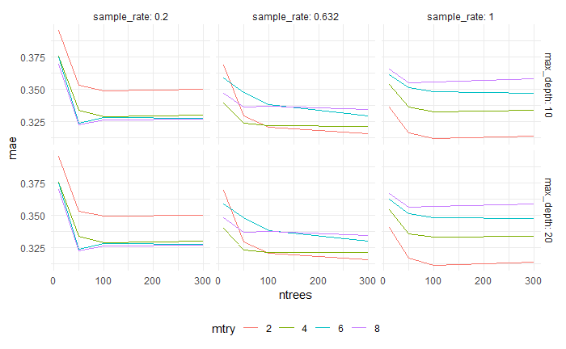

```r
rf_performance_summary <- as_tibble(h2o.getGrid(rf_grid@grid_id, "mae")@summary_table) %>%
  as_tibble() %>%
  mutate(across(c("mae", names(rf_params)), as.numeric))
ggplot(rf_performance_summary, aes(ntrees, mae, color = factor(mtries))) +
  geom_line() +
  facet_grid(max_depth ~ sample_rate, labeller = label_both) +
  theme(legend.position = "bottom") +
  labs(color = "mtry")
```

### Variable importance

With the ensemble models we have a hard time with interpretation. Variable importance measures can help to see which features contribute most to the predictive power of models. Variable importance is determined by calculating the relative influence of each variable: whether that variable was selected to split on during the tree building process, and how much the squared error (over all trees) improved (decreased) as a result.

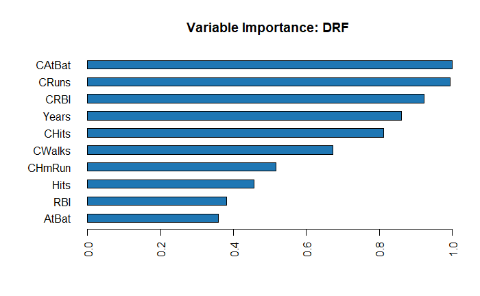

```r
h2o.varimp_plot(best_rf)
```

### Partial dependence

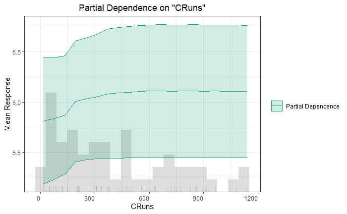

```r
h2o.pd_plot(best_rf, data_valid, "CRuns")
```

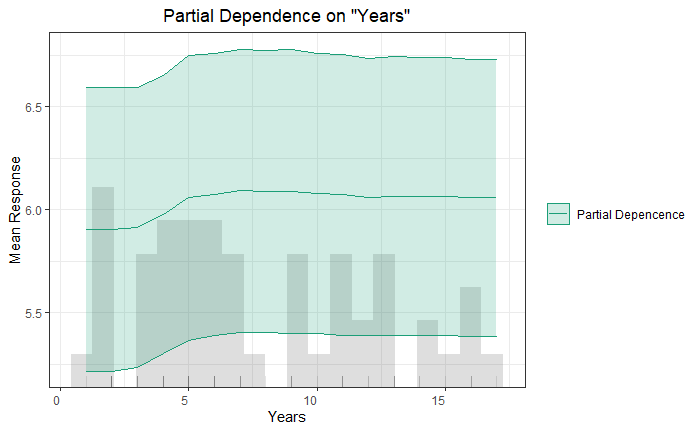

```r
h2o.pd_plot(best_rf, data_valid, "Years")
```

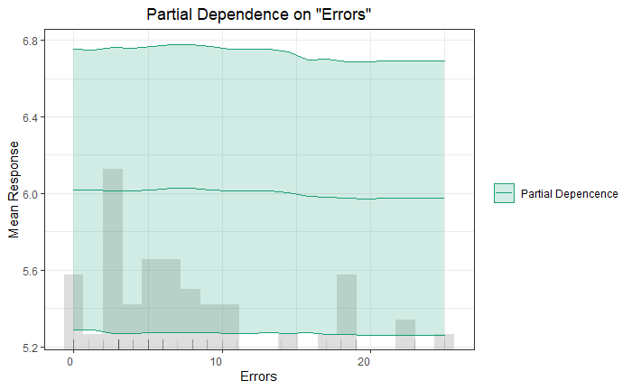

```r
h2o.pd_plot(best_rf, data_valid, "Errors")
```

I advise you to look at the [Model Explainability](https://docs.h2o.ai/h2o/latest-stable/h2o-docs/explain.html#) section of H2O’s documentation to see other tools that help you understand your model predictions.